# *Atividade 1 – Probabilidade e Estatistica*

## 1. Análise Exploratória do German Credit Data

### 1.1 Sobre o banco

A base de dados utilizada contém informações de clientes e se eles pagaram ou não empréstimos, usado para análise de risco de crédito. Num dataframe de 1000 x 21 com todas essas informações. Será apresentado logo abaixo as 10 primeiras linhas do dataframe usado.

| Status_conta | Meses_existencia | Historico_credito | Proposito | Valor_credito | Saldo_poupanca | Tempo_emprego | Taxa_parcela_renda | Status_pessoal_sexo | Fiador | Residencia_atual | Bens | Idade | Planos_parcelamento | Moradia | Credito_existente | Emprego | Dependentes | Telefone | Trabalhador_estrangeiro | Classe |
| --- | --- | --- | --- | --- | --- | --- | --- | --- | --- | --- | --- | --- | --- | --- | --- | --- | --- | --- | --- | --- |
| A11 | 6 | A34 | A43 | 1169 | A65 | A75 | 4 | A93 | A101 | 4.1 | A121 | 67 | A143 | A152 | 2 | A173 | 1 | A192 | A201 | 1 |
| A12 | 48 | A32 | A43 | 5951 | A61 | A73 | 2 | A92 | A101 | 2.0 | A121 | 22 | A143 | A152 | 1 | A173 | 1 | A191 | A201 | 2 |
| A14 | 12 | A34 | A46 | 2096 | A61 | A74 | 2 | A93 | A101 | 3.0 | A121 | 49 | A143 | A152 | 1 | A172 | 2 | A191 | A201 | 1 |
| A11 | 42 | A32 | A42 | 7882 | A61 | A74 | 2 | A93 | A103 | 4.0 | A122 | 45 | A143 | A153 | 1 | A173 | 2 | A191 | A201 | 1 |
| A11 | 24 | A33 | A40 | 4870 | A61 | A73 | 3 | A93 | A101 | 4.0 | A124 | 53 | A143 | A153 | 2 | A173 | 2 | A191 | A201 | 2 |
| A14 | 36 | A32 | A46 | 9055 | A65 | A73 | 2 | A93 | A101 | 4.0 | A124 | 35 | A143 | A153 | 1 | A172 | 2 | A192 | A201 | 1 |
| A14 | 24 | A32 | A42 | 2835 | A63 | A75 | 3 | A93 | A101 | 4.0 | A122 | 53 | A143 | A152 | 1 | A173 | 1 | A191 | A201 | 1 |
| A12 | 36 | A32 | A41 | 6948 | A61 | A73 | 2 | A93 | A101 | 2.0 | A123 | 35 | A143 | A151 | 1 | A174 | 1 | A192 | A201 | 1 |
| A14 | 12 | A32 | A43 | 3059 | A64 | A74 | 2 | A91 | A101 | 4.0 | A121 | 61 | A143 | A152 | 1 | A172 | 1 | A191 | A201 | 1 |
| A12 | 30 | A34 | A40 | 5234 | A61 | A71 | 4 | A94 | A101 | 2.0 | A123 | 28 | A143 | A152 | 2 | A174 | 1 | A191 | A201 | 2 |

Abaixo está algumas informações sobre dados faltantes , a classe de cada variável e outliers:

```
## [1] "Matriz mostrando todos os dados faltantes"
```

```
##            Status_conta        Meses_existencia       Historico_credito
##                       0                       0                       0
##               Proposito           Valor_credito          Saldo_poupanca
##                       0                       0                       0
##           Tempo_emprego      Taxa_parcela_renda     Status_pessoal_sexo
##                       0                       0                       0
##                  Fiador        Residencia_atual                    Bens
##                       0                       0                       0
##                   Idade     Planos_parcelamento                 Moradia
##                       0                       0                       0
##       Credito_existente                 Emprego             Dependentes
##                       0                       0                       0
##                Telefone Trabalhador_estrangeiro                  Classe
##                       0                       0                       0
```

```
## [1] "Classes das colunas"
```

```
##            Status_conta        Meses_existencia       Historico_credito
##             "character"               "numeric"             "character"
##               Proposito           Valor_credito          Saldo_poupanca
##             "character"               "numeric"             "character"
##           Tempo_emprego      Taxa_parcela_renda     Status_pessoal_sexo
##             "character"               "numeric"             "character"
##                  Fiador        Residencia_atual                    Bens
##             "character"               "numeric"             "character"
##                   Idade     Planos_parcelamento                 Moradia
##               "numeric"             "character"             "character"
##       Credito_existente                 Emprego             Dependentes
##               "numeric"             "character"               "numeric"
##                Telefone Trabalhador_estrangeiro                  Classe
##             "character"             "character"             "character"
```

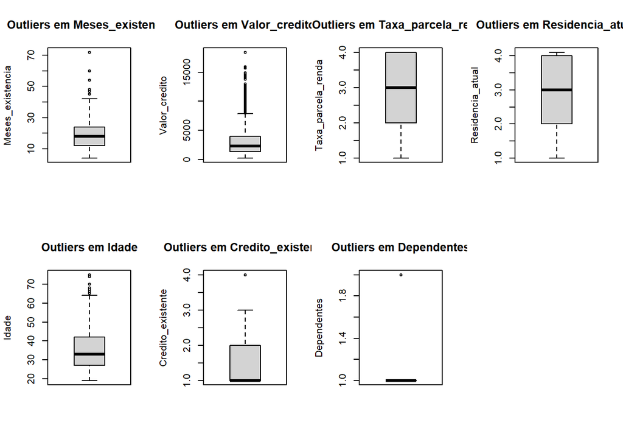

### 1.2 Colunas do banco

Variáveis Nnúmerias Chave (Usada em gráfcos e correlações);

| Variável | Descrição |
| --- | --- |
| Valor_credito | Valor do crédito solicitado (DM) |
| Meses_existencia | Duração do crédito em meses |
| Idade | Idade do cliente |
| Residencia_atual | Tempo na residência (meses) |

Variáveis Categóricas Principais (Usadas em gráficos bivariados);

| Variável | Descrição |
| --- | --- |
| Saldo_poupanca | <100 DM, 100-500 DM, 500-1000 DM, ≥1000 DM, Desconhecido |
| Tempo_emprego | Desempregado, <1 ano, 1-4 anos, 4-7 anos, ≥7 anos |
| Classe | 1 = Bom, 2 = Ruim |

Variáveis Secundárias Referenciadas:

| Variável | Usado em |
| --- | --- |
| Status_conta | Contexto para interpretação |
| Historico_credito | Discussão de riscos |
| Taxa_parcela_renda | Matriz de correlação |

## 2. Operações com uma coluna numérica

Cálculo do valor mínimo e o máximo valor, média, mediana, desvio padrão, os quartis, construição do histograma e do boxplot. Coluna usada: “Valor_Credito”.

| Estatisticas | Valores |
| --- | --- |
| Mínimo | 250.000 |
| Máximo | 18424.000 |
| Média | 3271.258 |
| Mediana | 2319.500 |
| Desvio Padrão | 2822.737 |
| 25% | 1365.500 |
| 50% | 2319.500 |
| 75% | 3972.250 |

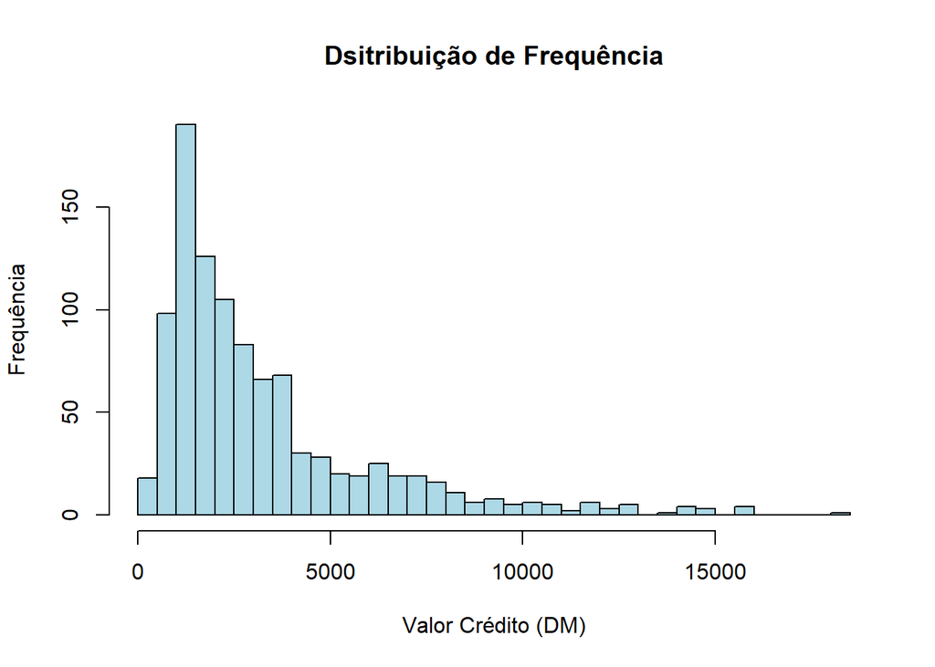

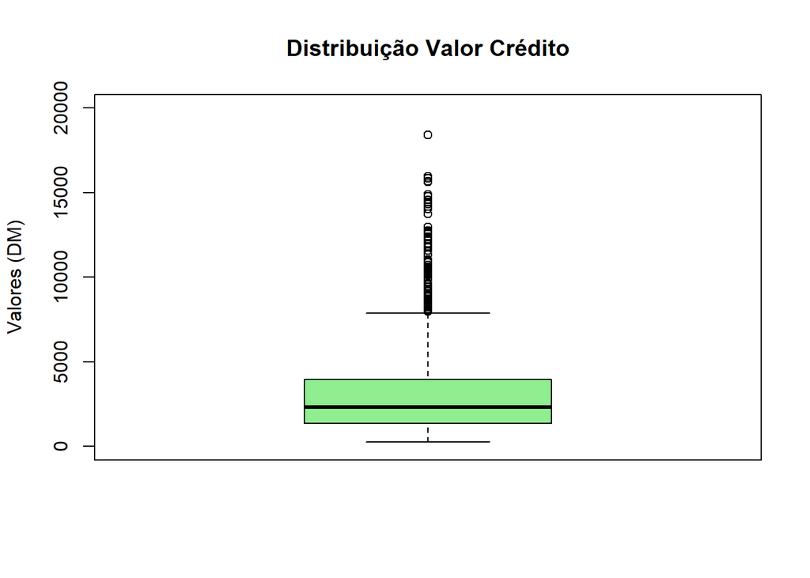

- Interpretações acerca dos fatos:
  - A média é maior que a mediana, ou seja, há uma concentração em valores mais baixos;
  - DP é elevado o que pode indicar uma disperção grande nos dados;
  - Histograma: valores concentrados na esquerda e uma cauda alongada para direita, uma frequência máxima em intervalos menores o cabe com a mediana e com valores acima de 10000 bem raros;
  - Boxplot: Temos outliers bem visíveis, com pontos acima de 10000 DM e cerca de 75% dos dados estão abaico de 3972.25 DM;
  - A maioria dos crédicos é pequena com pouco valores altos;
  - Alguns fatores: imprevistos, renda limitada, sem reservas de dinheiro, etc.